# stats final

2026-02-26

```r
bike_data <- read.csv("bikes.csv", header = TRUE)

bike_data_clean <- na.omit(bike_data)

nrow(bike_data)
```

```
## [1] 17379
```

```r
nrow(bike_data_clean)
```

```
## [1] 17379
```

lets see how hours affect the bike rentals. we can see if there are any rush hours in days or if there are any outliers

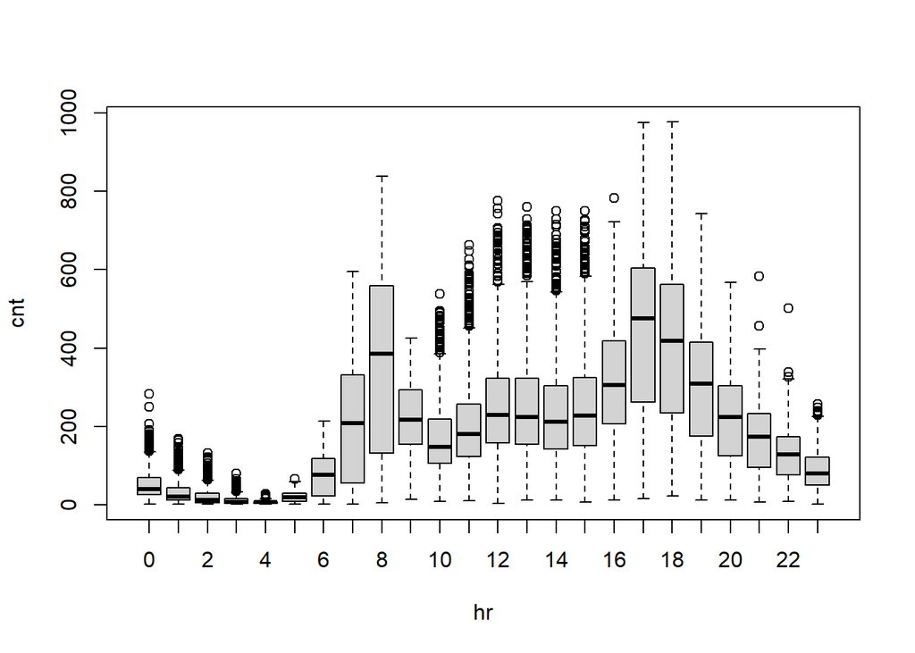

```r
boxplot(cnt ~ hr, data = bike_data_clean)
```

```r
  main = "hourly bike rentals"
  xlab = "hour of day (0-23)"
  ylab = "total rentals"
  col = "skyblue"
```

```r
hourly_stats <- aggregate(cnt ~ hr, data = bike_data_clean,
                          FUN = function(x) c(mean = mean(x), max = max(x), sd = sd(x)))
  print(hourly_stats)
```

```
##    hr   cnt.mean    cnt.max     cnt.sd
## 1   0  53.898072 283.000000  42.307910
## 2   1  33.375691 168.000000  33.538727
## 3   2  22.869930 132.000000  26.578642
## 4   3  11.727403  79.000000  13.239190
## 5   4   6.352941  28.000000   4.143818
## 6   5  19.889819  66.000000  13.200765
## 7   6  76.044138 213.000000  55.084348
## 8   7 212.064649 596.000000 161.441936
## 9   8 359.011004 839.000000 235.189285
## 10  9 219.309491 426.000000  93.703458
## 11 10 173.668501 539.000000 102.205413
## 12 11 208.143054 663.000000 127.495536
## 13 12 253.315934 776.000000 145.081134
## 14 13 253.661180 760.000000 148.107657
## 15 14 240.949246 750.000000 147.271574
## 16 15 251.233196 750.000000 144.632541
## 17 16 311.983562 783.000000 148.682618
## 18 17 461.452055 976.000000 232.656611
## 19 18 425.510989 977.000000 224.639304
## 20 19 311.523352 743.000000 161.050359
## 21 20 226.030220 567.000000 119.670164
## 22 21 172.314560 584.000000  89.788893
## 23 22 131.335165 502.000000  69.937782
## 24 23  87.831044 256.000000  50.846889
```

this next data confirms that these maximums exist as they seem a little high

```r
high_rentals <- subset(bike_data_clean, cnt >= 800)

nrow(high_rentals)
```

```
## [1] 149
```

now that we have completed analysis of our first argument, that the time of day affects bike rentals, we can begin looking into the data of how weather patterns affect bike rentals. in order to make sure that we are looking only at how weather affects the data and not time, we will only look at data from the hour 17:00 as this has the highest number of average rentals.

in order to effectively keep time as a constant we are going to create a new data set that has only the data of 1700 hours.

```r
bike_1700 <- subset(bike_data_clean, hr == 17)
```

we can now see how many observations we have in this data set

```r
nrow(bike_1700)
```

```
## [1] 730
```

we have 730 observations. we can now use multiple linear regression to see how weather situation, apparent temperature, humidity, and wind speed factor into the overall count of rented bikes. in this case we are taking weather situation to mean how the overall weather of the time is with 1 = clear/partly cloudy 2 = mist + cloudy 3 = light snow/ light rain 4 = heavy rain/ ice/ snow It should also be noted that we are choosing apparent temperature over actual temperature as apparent temperature will have a higher impact on human behavior of bike rental

```r
weather_model <- lm(cnt ~ atemp + hum + windspeed + factor(weathersit), data = bike_1700)

summary(weather_model)
```

```
##
## Call:
## lm(formula = cnt ~ atemp + hum + windspeed + factor(weathersit),
##     data = bike_1700)
##
## Residuals:
##     Min      1Q  Median      3Q     Max
## -564.36 -127.84   -9.45  123.48  511.66
##
## Coefficients:
##                     Estimate Std. Error t value Pr(>|t|)
## (Intercept)          153.070     34.211   4.474 8.90e-06 ***
## atemp                751.074     39.284  19.119  < 2e-16 ***
## hum                 -131.775     44.284  -2.976  0.00302 **
## windspeed            -12.487     52.543  -0.238  0.81222
## factor(weathersit)2   -5.134     18.510  -0.277  0.78157
## factor(weathersit)3 -124.790     27.545  -4.530 6.89e-06 ***
## ---
## Signif. codes:  0 '***' 0.001 '**' 0.01 '*' 0.05 '.' 0.1 ' ' 1
##
## Residual standard error: 180.5 on 724 degrees of freedom
## Multiple R-squared:  0.4023, Adjusted R-squared:  0.3981
## F-statistic: 97.45 on 5 and 724 DF,  p-value: < 2.2e-16
```

from the table above we can see that windspeed and weathersit 2 (misty or cloudy weather) are NOT statistically significant in being a deciding factor for the number of bikes rented at this time. but apparent temperature and humidity are the biggest deciding factors, as well as rain. A R squared value of .3981 points to about 40% of the variation in bike rentals at this time being explained by the weather.

it should be noted that our data summary did not include anything on factor(weathesit)4 which is our heavy snow/rain/ice catagory. this would imply that there was not a single day where this weather was present at 1700 hours. to doublecheck that this is accurate we will run the following code

```r
table(bike_1700$weathersit)
```

```
##
##   1   2   3
## 507 147  76
```

from this data we can see that there is no heavy weather situation at any point at 1700 hours in our data set.

furthermore, since windpseed is the least significant for our model, we can eliminate it to create a simpler model.

```r
weather_model2 <- lm(cnt ~ atemp + hum + factor(weathersit), data = bike_1700)

summary(weather_model2)
```

```
##
## Call:
## lm(formula = cnt ~ atemp + hum + factor(weathersit), data = bike_1700)
##
## Residuals:
##     Min      1Q  Median      3Q     Max
## -563.17 -128.01   -9.25  123.60  512.20
##
## Coefficients:
##                     Estimate Std. Error t value Pr(>|t|)
## (Intercept)          149.199     30.065   4.962 8.68e-07 ***
## atemp                751.476     39.222  19.160  < 2e-16 ***
## hum                 -130.074     43.672  -2.978  0.00299 **
## factor(weathersit)2   -5.214     18.494  -0.282  0.77810
## factor(weathersit)3 -125.859     27.158  -4.634 4.25e-06 ***
## ---
## Signif. codes:  0 '***' 0.001 '**' 0.01 '*' 0.05 '.' 0.1 ' ' 1
##
## Residual standard error: 180.4 on 725 degrees of freedom
## Multiple R-squared:  0.4022, Adjusted R-squared:  0.3989
## F-statistic:   122 on 4 and 725 DF,  p-value: < 2.2e-16
```

furthermore we can see that weathersit 2 (misty/cloudy weather) also has a Pval > .05 meaning it is not significant. we can eliminate it from our model to just have our variables focuse on apparent temperature, humidity, and whether or not it is raining/snowing

in order to do this we will make a data set where we have weathersit 1 and 2 be set as not rain (0) and weather sit 3 and 4 be set as rain (1)

```r
bike_1700$is_rainy_1700 <- ifelse(bike_1700$weathersit >= 3, 1, 0)

weather_model3 <- lm(cnt ~ atemp + hum + is_rainy_1700, data = bike_1700)

summary(weather_model3)
```

```
##
## Call:
## lm(formula = cnt ~ atemp + hum + is_rainy_1700, data = bike_1700)
##
## Residuals:
##     Min      1Q  Median      3Q     Max
## -563.01 -127.43   -9.48  122.99  511.18
##
## Coefficients:
##               Estimate Std. Error t value Pr(>|t|)
## (Intercept)     149.45      30.03   4.976 8.11e-07 ***
## atemp           753.04      38.80  19.406  < 2e-16 ***
## hum            -134.75      40.37  -3.338 0.000888 ***
## is_rainy_1700  -123.12      25.34  -4.858 1.45e-06 ***
## ---
## Signif. codes:  0 '***' 0.001 '**' 0.01 '*' 0.05 '.' 0.1 ' ' 1
##
## Residual standard error: 180.3 on 726 degrees of freedom
## Multiple R-squared:  0.4022, Adjusted R-squared:  0.3997
## F-statistic: 162.8 on 3 and 726 DF,  p-value: < 2.2e-16
```

here we see that we now have a model where all variables are significant. our new adjusted R^2 is .3997 which is greater than before.

using all of this data we can come up with our equation of Count = 149.45 + 753.04(atemp) - 134.75(hum) - 123.12(is_rainy)

to continue analysis of our data set, we are now going to compare the count of bikes bought on a working day versus a non working day (weekends and holidays) we can do this with a simple t test

```r
day_comparison_results <- t.test(cnt ~ workingday, data = bike_data_clean)
print(day_comparison_results)
```

```
##
##  Welch Two Sample t-test
##
## data:  cnt by workingday
## t = -4.0951, df = 11445, p-value = 4.249e-05
## alternative hypothesis: true difference in means between group 0 and group 1 is not equal to 0
## 95 percent confidence interval:
##  -17.451845  -6.152999
## sample estimates:
## mean in group 0 mean in group 1
##        181.4053        193.2078
```

now that we know that there is a difference, we can see just how much of a difference there is between the types of days

```r
aggregate(cnt ~ workingday, data = bike_data_clean, FUN = mean)
```

```
##   workingday      cnt
## 1          0 181.4053
## 2          1 193.2078
```

this data shows us that on average, there are more bikes being rented on WORKING DAYS than on non working days by 12 rentals per hour

this data suggests that commuter rush, that 0800 and 1700 rush, is enough to edge out leisure riding.

we now move into our final analysis, using multiple linear regression to create a master model to predict count overall. this model will take into account the apparent temperature, the humidity, rain, whether or not it is a workday, and time

```r
# we have to recreate our data set for if its rainy for the whole data instead of just 1700
bike_data_clean$is_rainy_master <- ifelse(bike_data_clean$weathersit >= 3, 1, 0)

master_model <- lm(cnt ~ atemp + hum + is_rainy_master + workingday + factor(hr), data = bike_data_clean)

summary(master_model)
```

```
##
## Call:
## lm(formula = cnt ~ atemp + hum + is_rainy_master + workingday +
##     factor(hr), data = bike_data_clean)
##
## Residuals:
##     Min      1Q  Median      3Q     Max
## -390.44  -63.65   -7.67   49.17  508.29
##
## Coefficients:
##                 Estimate Std. Error t value Pr(>|t|)
## (Intercept)      -33.346      6.021  -5.538 3.10e-08 ***
## atemp            318.308      5.181  61.442  < 2e-16 ***
## hum              -81.706      5.408 -15.110  < 2e-16 ***
## is_rainy_master  -62.215      3.382 -18.398  < 2e-16 ***
## workingday         6.689      1.852   3.612 0.000305 ***
## factor(hr)1      -16.681      5.955  -2.801 0.005101 **
## factor(hr)2      -24.695      5.975  -4.133 3.60e-05 ***
## factor(hr)3      -34.535      6.016  -5.740 9.61e-09 ***
## factor(hr)4      -36.752      6.019  -6.106 1.05e-09 ***
## factor(hr)5      -21.120      5.979  -3.533 0.000413 ***
## factor(hr)6       36.846      5.962   6.180 6.56e-10 ***
## factor(hr)7      171.098      5.954  28.738  < 2e-16 ***
## factor(hr)8      310.028      5.949  52.112  < 2e-16 ***
## factor(hr)9      160.764      5.951  27.014  < 2e-16 ***
## factor(hr)10     105.127      5.965  17.624  < 2e-16 ***
## factor(hr)11     129.285      5.990  21.584  < 2e-16 ***
## factor(hr)12     167.386      6.018  27.813  < 2e-16 ***
## factor(hr)13     161.917      6.043  26.794  < 2e-16 ***
## factor(hr)14     145.501      6.062  24.003  < 2e-16 ***
## factor(hr)15     155.048      6.070  25.545  < 2e-16 ***
## factor(hr)16     217.746      6.063  35.911  < 2e-16 ***
## factor(hr)17     372.107      6.045  61.559  < 2e-16 ***
## factor(hr)18     340.848      6.023  56.589  < 2e-16 ***
## factor(hr)19     233.126      5.990  38.917  < 2e-16 ***
## factor(hr)20     154.668      5.973  25.892  < 2e-16 ***
## factor(hr)21     105.881      5.958  17.771  < 2e-16 ***
## factor(hr)22      69.669      5.951  11.707  < 2e-16 ***
## factor(hr)23      31.524      5.948   5.300 1.17e-07 ***
## ---
## Signif. codes:  0 '***' 0.001 '**' 0.01 '*' 0.05 '.' 0.1 ' ' 1
##
## Residual standard error: 113.4 on 17351 degrees of freedom
## Multiple R-squared:  0.6099, Adjusted R-squared:  0.6093
## F-statistic:  1005 on 27 and 17351 DF,  p-value: < 2.2e-16
```

from the data we can see that all of our variables are statistically significant and with an adjusted R squared we have a very strong data set.

our final equation for the counts that occur in a given hour are cnt = -33.346 + 318.308(atemp) - 81.706(hum) - 62.215(is_rainy_master) +/- factor(hr)

we can plot this with the command

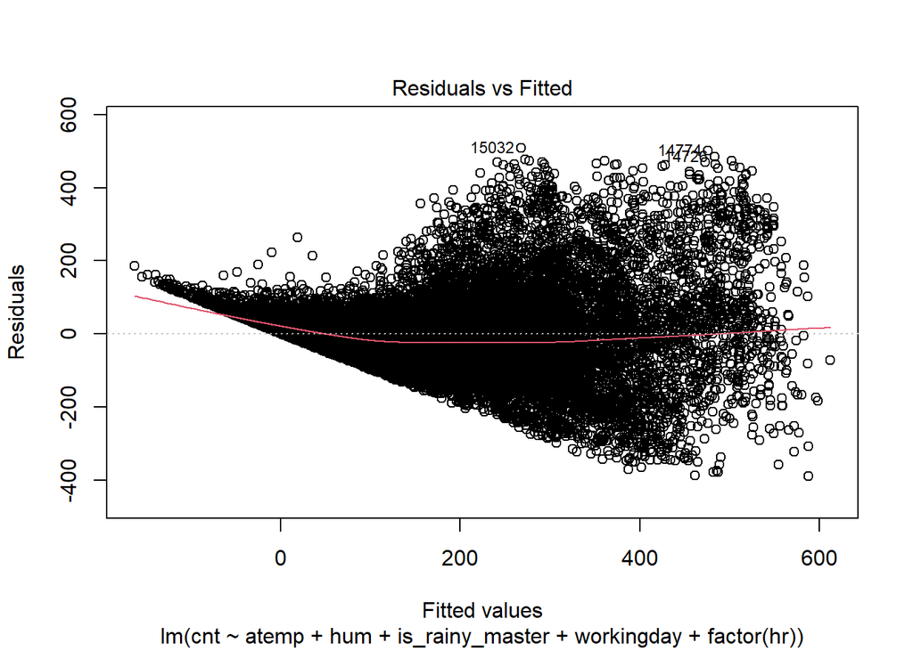

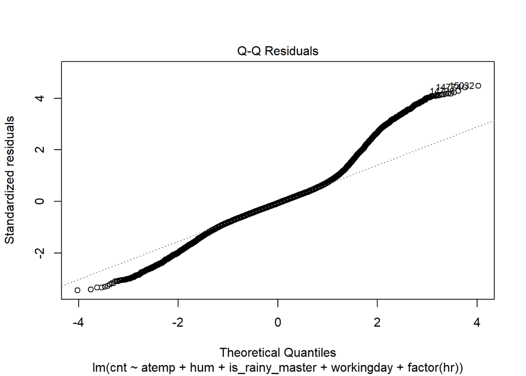

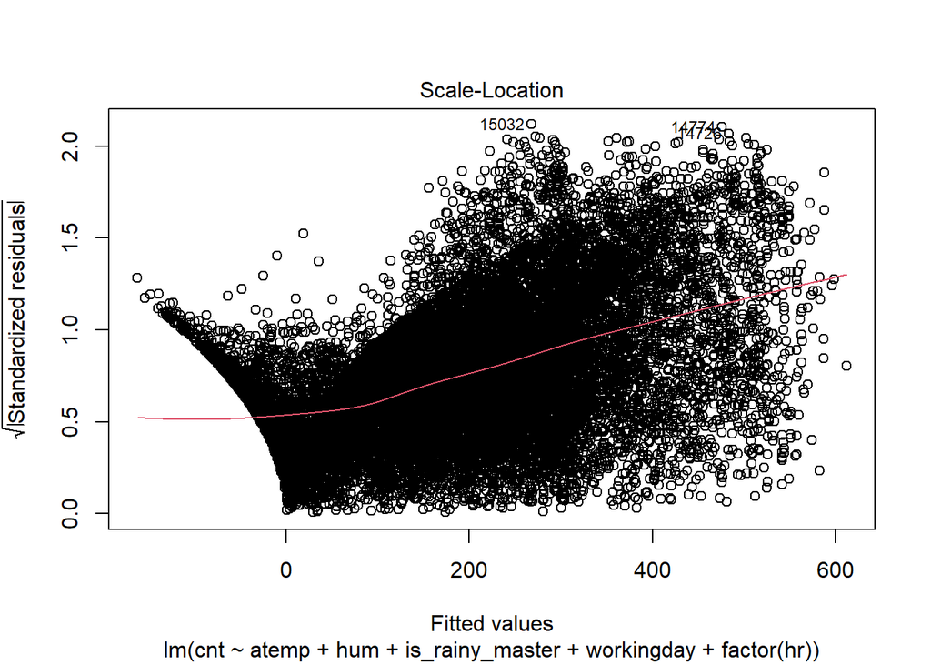

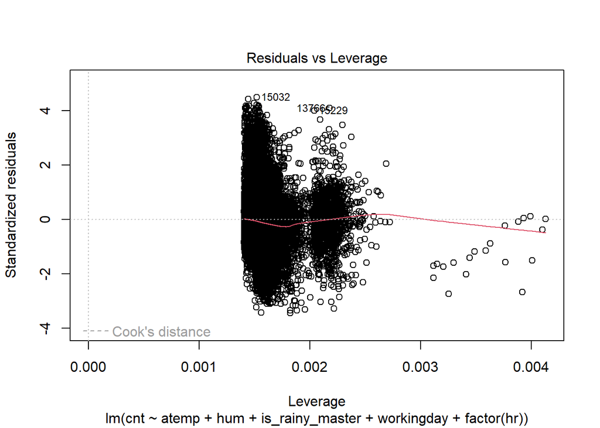

```r
plot(master_model)
```

from the plots we can see that while our model mostly fits the values, there are still some outliers that apply randomness (which is what we expect with a adjusted R squared of .6). this randomness could be attributed to human chaos and normal behavior (humans arnt perfectly programmable models)

however to test our model we can run a prediction and see how it matches up to the real data. lets take a day that is a normal working day (1), in clear weather (is_rainy = 0), with average temp and average humidity. first we will have to find the average temp and average humidity and then we can fit them into our model.

```r
mean_atemp <- mean(bike_data_clean$atemp)
mean_hum <- mean(bike_data_clean$hum)

print(paste("average normalized temp:", round(mean_atemp, 3)))
```

```
## [1] "average normalized temp: 0.476"
```

```r
print(paste("average normalized humidity:", round(mean_hum, 3)))
```

```
## [1] "average normalized humidity: 0.627"
```

now that we have the averages we can make our predictions for an average non rainy working day at 1700 hours

```r
new_day <- data.frame(
  hr = 17,
  workingday = 1,
  atemp = mean_atemp,
  hum = mean_hum,
  is_rainy_master = 0
)

predicted_count <- predict(master_model, newdata = new_day)
print(paste("predicted rentals at 5 pm:", round(predicted_count)))
```

```
## [1] "predicted rentals at 5 pm: 446"
```

the model shows that the predicted number of bikes for an average day at 5 pm in clear weather is 446, lets see how this compares to our actual data. to do this we will find a day that matches our prediction model with a +/- .05 difference in each catagory

```r
real_matches <- subset(bike_data_clean,
                       hr == 17 &
                         workingday == 1 &
                         is_rainy_master == 0 &
                         atemp >= (mean_atemp - 0.05) & atemp <= (mean_atemp + 0.05) &
                         hum >= (mean_hum - 0.05) & hum <= (mean_hum + 0.05))
nrow(real_matches)
```

```
## [1] 10
```

```r
#this will show how many days actually match the criteria and now we can average them
mean(real_matches$cnt)
```

```
## [1] 470.7
```

we can see that we have 10 matches in our entire data set for these conditions and these 10 days all have an average of 470.7 rentals. we can now find the percent error of our model to our actual data to see how close we are in the accuracy of our model

```r
actual_avg <- mean(real_matches$cnt)
predicted_val <- 446
percent_error <- (abs(actual_avg - predicted_val) / actual_avg)*100

print(paste("actual average rentals:", round(actual_avg, 2)))
```

```
## [1] "actual average rentals: 470.7"
```

```r
print(paste("predicted rentals:", predicted_val))
```

```
## [1] "predicted rentals: 446"
```

```r
print(paste("percent error:", round(percent_error, 2), "%"))
```

```
## [1] "percent error: 5.25 %"
```

we got a percent error of 5.25% which means our model is extremely strong as a predictor ;)